# Combined Density RA

Frank

2022-05-30

# Introduction

These are the codes I used to run basic reciprocal averaging for my combined density data (part a) using the function decorana() from the *vegan* package (Oksanen et al. 2022).

# Test run

First, I want to try out this function by using the same dataset that I ran in PC-ORD version 7.09 (McCune and Mefford, 2016).

## Load data

```r
library(readxl)
count_partb <- read_excel("~/thesis-codes/Part b (09-19)/RA (count)/Count Part b.xlsx",
    sheet = "Count")
```

## Make a matrix from count data

```r
m_count_partb <- as.matrix(count_partb[,4:ncol(count_partb)]) #exclude the first column that contains SU information
```

## Run CA/RA

```r
library(vegan)
ra_count_partb <- decorana(m_count_partb, iweigh=0, iresc=4, ira=1, short=0, before=NULL, after=NULL) #no rare spp downweighting;no rescaling; basic RA;
```

## Add columns of Site, Year, Subwatershed

Again, I add columns to the existing dataset by using pipes from the *dplyr* package (Wickham et al., 2022).

```r
library(dplyr) #load the package
data.scores <- as.data.frame(ra_count_partb$rproj) #this is to extract site scores
data.scores.dplyr <- data.scores %>% mutate(Site = count_partb$Site,Year=count_partb$Year,
                                            Subwatershed=count_partb$Subwatershed) %>% relocate(Site, Year,
                                                                                                Subwatershed)
head(data.scores.dplyr)
```

```
##   Site Year Subwatershed         RA1         RA2        RA3        RA4
## 1   B1 2015           B1  0.24777670  0.35397883 -0.2565207 -0.2462255
## 2   B5 2015           B1 -0.04005602 -0.04121631 -0.2019329 -0.4469857
## 3   B7 2015           B7  2.56290863 -1.33742912 -0.1844083 -0.1540035
## 4  B10 2015          B9A  0.67047304  1.39308762 -1.1459170  1.2122555
## 5  REF 2015           B1 -0.65603562 -0.51285260 -0.4728799  0.2561581
## 6   B1 2017           B1 -0.09198814  0.39513611  0.5919194 -0.3436318
```

## Plot the graph using *ggplot2*

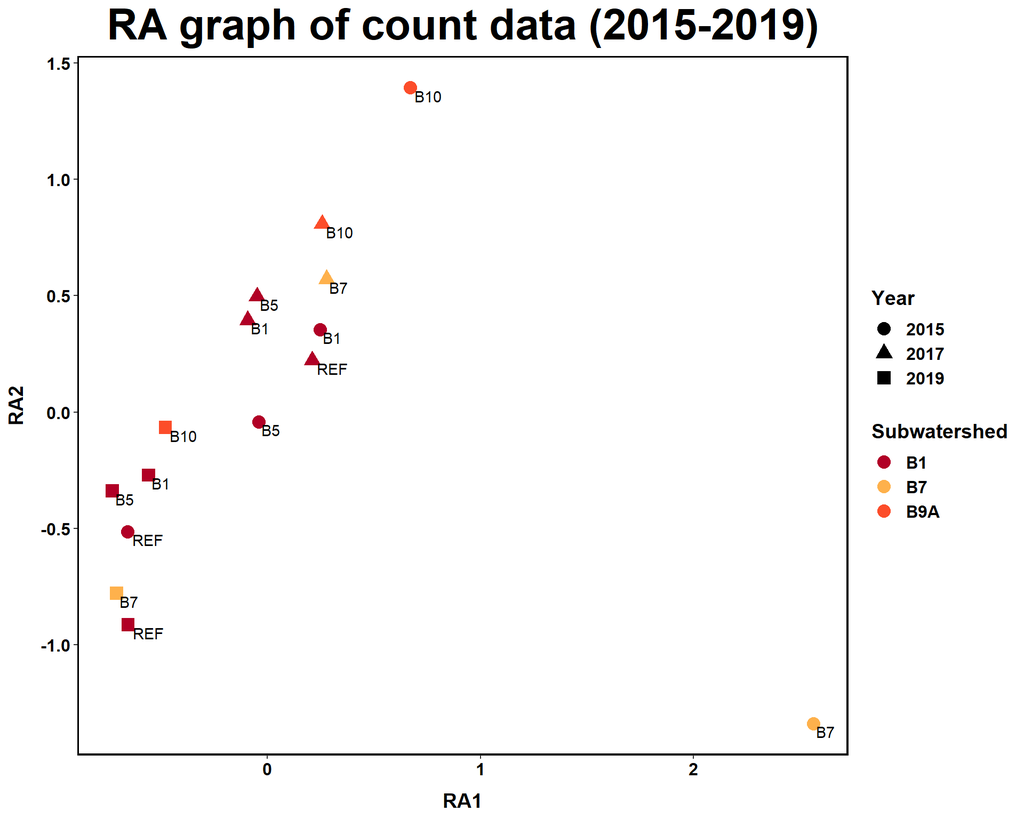

```r
library(ggplot2) #load the package

count_partb_graph <- ggplot(data.scores.dplyr, aes(x = RA1, y = RA2)) +
    geom_point(size = 4,aes( shape = as.character(Year), colour = Subwatershed))+ # geom_polygon(data=data.scores.dplyr,aes(x = RA1, y = RA2,group=Subwatershed),alpha=0.30); this is to add a little convex polygon to visualize the clusters better. You can try to see how it looks.
    theme(axis.text.y = element_text(colour = "black", size = 12, face = "bold"),
    axis.text.x = element_text(colour = "black", face = "bold", size = 12),
    legend.text = element_text(size = 12, face ="bold", colour ="black"),
    legend.position = "right", axis.title.y = element_text(face = "bold", size = 14),
    axis.title.x = element_text(face = "bold", size = 14, colour = "black"),
    legend.title = element_text(size = 14, colour = "black", face = "bold"),
    panel.background = element_blank(), panel.border = element_rect(colour = "black", fill = NA, size = 1.2),
    legend.key=element_blank(),
    plot.title = element_text(color = "black", size = 30, face = "bold", hjust = 0.5)) +
    labs(
    title = "RA graph of count data (2015-2019)") +
    theme(axis.title.x = element_text(margin=margin(t=10)), #add margin to x-axis title
          axis.title.y = element_text(margin=margin(r=10)))+
    labs(x = "RA1", colour = "Subwatershed", y = "RA2", shape = "Year")  +
    scale_colour_manual(values = c("#b10026", "#feb14c","#fc4d2a")) +
    geom_text(aes(label=Site),hjust=-0.15, vjust=1.2)

count_partb_graph
```

```r
ggsave("Part B Count RA graph.jpeg",count_partb_graph,width=15,height=8)
```

# Real data

## Load data

Nice, now that I have confirmed that my codes for RA have worked and produced the same results generated by PC-ORD version 7.09 (McCune and Mefford, 2016), I am going to use the same codes for my other dataset.

```r
library(readxl)
density_combined <- read_excel("~/thesis-codes/Part a (87-09)/RA (combined density)/density_combined.xlsx",
    sheet = "Final")
```

## Make a matrix from abundance data

```r
m_density_combined <- as.matrix(density_combined[,4:ncol(density_combined)]) #exclude the first column that contains SU information
```

## Run CA/RA

```r
library(vegan)
ra_density_combined <- decorana(m_density_combined, iweigh=0, iresc=4, ira=1, short=0, before=NULL, after=NULL) #no rare spp downweighting;no rescaling; basic RA;
```

## Add columns of Site, Year, Subwatershed

Again, I add columns to the existing dataset by using pipes from the *dplyr* package (Wickham et al., 2022).

```r
library(dplyr) #load the package
data.scores <- as.data.frame(ra_density_combined$rproj) #this is to extract site scores
data.scores.dplyr <- data.scores %>% mutate(Site = density_combined$Site,Year=density_combined$Year,
                                            Subwatershed=density_combined$Subwatershed) %>% relocate(Site, Year,
                                                                                                     Subwatershed)
head(data.scores.dplyr)
```

```
##   Site      Year Subwatershed       RA1        RA2         RA3         RA4
## 1   B1 1987-1988           B1 0.9775763 -0.7942114 -0.13570811  0.03498867
## 2   B2 1987-1988           B1 0.7368090 -0.6738703  0.11327041 -0.02727801
## 3   B3 1987-1988           B1 0.8233325 -0.5929189  0.01619114 -0.29177196
## 4   B4 1987-1988           B1 0.6901656 -0.2893593  0.19171759 -0.32415977
## 5   B5 1987-1988           B1 1.0273260  0.4074791 -0.03716040 -0.82147778
## 6   B7 1987-1988           B7 1.0282250  1.3610880 -0.22472660  0.49493718
```

## Plot the graph using *ggplot2*

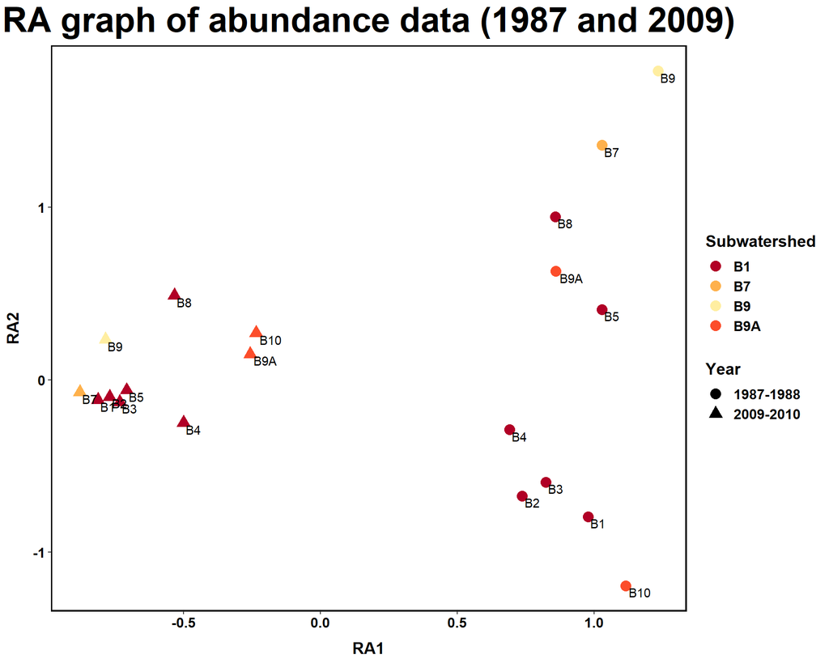

```r
library(ggplot2) #load the package

combined_density_ra_graph <- ggplot(data.scores.dplyr, aes(x = RA1, y = RA2)) +
    geom_point(size = 4,aes( shape = Year, colour = Subwatershed))+ # geom_polygon(data=data.scores.dplyr,aes(x = RA1, y = RA2,group=Subwatershed),alpha=0.30); this is to add a little convex polygon to visualize the clusters better. You can try to see how it looks.
    theme(axis.text.y = element_text(colour = "black", size = 12, face = "bold"),
    axis.text.x = element_text(colour = "black", face = "bold", size = 12),
    legend.text = element_text(size = 12, face ="bold", colour ="black"),
    legend.position = "right", axis.title.y = element_text(face = "bold", size = 14),
    axis.title.x = element_text(face = "bold", size = 14, colour = "black"),
    legend.title = element_text(size = 14, colour = "black", face = "bold"),
    panel.background = element_blank(), panel.border = element_rect(colour = "black", fill = NA, size = 1.2),
    legend.key=element_blank(),
    plot.title = element_text(color = "black", size = 30, face = "bold", hjust = 0.5)) +
    labs(
    title = "RA graph of abundance data (1987 and 2009)") +
    theme(axis.title.x = element_text(margin=margin(t=10)), #add margin to x-axis title
          axis.title.y = element_text(margin=margin(r=10)))+
    labs(x = "RA1", colour = "Subwatershed", y = "RA2", shape = "Year")  +
    scale_colour_manual(values = c("#b10026", "#feb14c","#ffeea1","#fc4d2a")) +
    geom_text(aes(label=Site),hjust=-0.15, vjust=1.2)

combined_density_ra_graph
```

```r
ggsave("Part A Abundance RA graph.jpeg",combined_density_ra_graph,width=15,height=8)
```

# References

1. Jari Oksanen, Gavin L. Simpson, F. Guillaume Blanchet, Roeland Kindt, Pierre Legendre, Peter R. Minchin, R.B. O’Hara, Peter Solymos, M. Henry H. Stevens, Eduard Szoecs, Helene Wagner, Matt Barbour, Michael Bedward, Ben Bolker, Daniel Borcard, Gustavo Carvalho, Michael Chirico, Miquel De Caceres, Sebastien Durand, Heloisa Beatriz Antoniazi Evangelista, Rich FitzJohn, Michael Friendly, Brendan Furneaux, Geoffrey Hannigan, Mark O. Hill, Leo Lahti, Dan McGlinn, Marie-Helene Ouellette, Eduardo Ribeiro Cunha, Tyler Smith, Adrian Stier, Cajo J.F. Ter Braak and James Weedon (2022). vegan: Community Ecology Package. R package version 2.6-2. https://CRAN.R-project.org/package=vegan
2. Hadley Wickham, Romain François, Lionel Henry and Kirill Müller (2022). dplyr: A Grammar of Data Manipulation. R package version 1.0.8. https://CRAN.R-project.org/package=dplyr
3. Hadley Wickham. ggplot2: Elegant Graphics for Data Analysis. Springer-Verlag New York, 2016.
4. McCune, B., & Mefford, M. J. (2016). PC-ORD. Multivariate Analysis of Ecological Data. Version 7. MjM Software Design, Gleneden Beach, Oregon, U.S.A.